# Identifying Latent Dimensions of Digital Engagement and Social Capital using the 2024 GSS

#### Histograms of Variables

Our variables divide into two categories. First, there are variables relating to demographic information of the respondent such as age, sex, and marital status. These will not be used in the main MCA analysis but will be used as supplementary variables. The second category consists of the variables that will be used for MCA analysis, and consist of questions relating the respondent’s usage of digital devices as well as questions relating to the respondent’s social life.

#### Demographic Variables (Supplementary Variables)

First, histograms of the supplemental demographic variables are shown below. The variable names are as follows:

| Variable Name | Variable Type | GSS Description |
| --- | --- | --- |
| AGE | Numeric (Integer) | Age of Respondent |
| ATTEND | Ordinal | How often Respondent attends religious services |
| CHILDS | Numeric (Integer) | Number of children |
| CLASS | Ordinal | Subjective class identification |
| EDUC | Numeric (Integer) | Highest year of school completed |
| MARITAL | Categorical | Marital Status of Respondent |
| RACECEN1.mod | Categorical | Race of Respondent (NOTE: recoded from original to have fewer categories) |
| RELPERSN | Ordinal (Likert) | Respondent consider self a religious person |
| RELACTIV | Ordinal | Frequency of attending religious activities other than services |
| RELTRAD | Categorical | Religious tradition |
| SEX | Categorical | Respondents sex |
| WRKSTAT | Categorical | Labor force status |

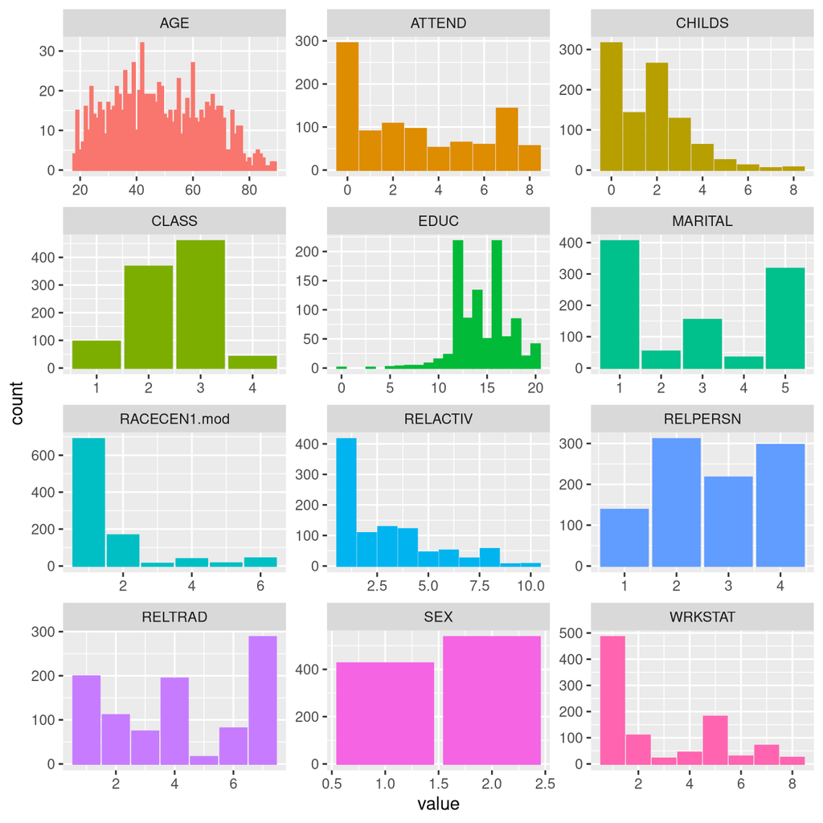

```r
suppVarNames = c("EDUC","CLASS","RACECEN1.mod","WRKSTAT","MARITAL","AGE","CHILDS","SEX","RELTRAD","ATTEND","RELPERSN", "RELACTIV")

supplementary.long <- data |> pivot_longer(all_of(suppVarNames),names_to = "variable", values_to = "value")

ggplot(supplementary.long, aes(x=value, color=variable,fill=variable)) +
  facet_wrap(~variable, scales='free', ncol=3) +
  geom_bar() +
  theme(legend.position = "none")
```

#### Digital Engagement Variables

Next, the histograms of variables relating to usage of and additutes towards digital technology are shown below:

| Variable Name | Variable Type | GSS Description |
| --- | --- | --- |
| INTAPPS | Ordinal (Likert) | Respondent’s skill at learning new software |
| INTCOMM | Ordinal (Likert) | How often Respondent uses internet for communication |
| INTFNCL | Ordinal (Likert) | How often Respondent uses internet for financial transactions |
| INTGAME | Ordinal (Likert) | How often Respondent uses internet for video games |
| INTHOME | Ordinal (Likert) | Frequency Respondent has home internet access |
| INTLITERACY | Ordinal (Likert) | Respondent’s knowledge of online information discretion |
| INTLNLY | Ordinal (Likert) | Respondent would feel lonely without internet? |
| INTMEET | Ordinal (Likert) | Respondent more comfortable meeting people online? |
| INTPRFSSNL | Ordinal (Likert) | Frequency Respondent has work/school internet access |
| INTPUB | Ordinal (Likert) | Frequency Respondent has internet access in public |
| INTRNETUSE | Ordinal (Likert) | Frequency of internet use over past 12 months |
| INTRUST | Ordinal (Likert) | How much Respondent trusts people they’ve only met online |
| INTSEARCH | Ordinal (Likert) | How often Respondent uses internet for search |
| INTSHARE | Ordinal (Likert) | How often Respondent uses internet for sharing photos/videos |
| INTSKILL | Ordinal (Likert) | Respondent’s skill at using the internet |
| INTSTREAM | Ordinal (Likert) | How often Respondent uses internet for music/video |
| INTSURF | Ordinal (Likert) | Respondent’s skill at online searches |
| INTVIEWS | Ordinal (Likert) | How often Respondent talks about politics online |
| UNPLUG | Ordinal (Likert) | Amount Respondent reduced time spent on internet in last 12 months |

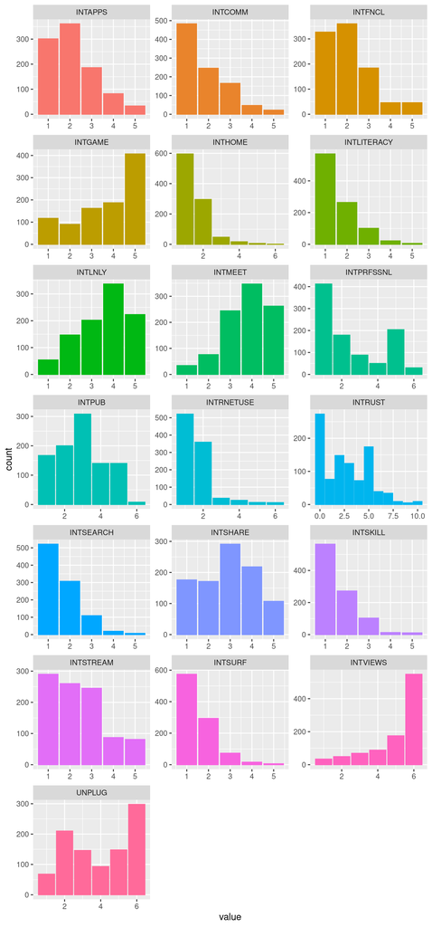

```r
digitalVarNames = c("INTRNETUSE", "INTPRFSSNL", "UNPLUG", "INTHOME", "INTPUB", "INTSKILL", "INTSURF", "INTLITERACY", "INTAPPS", "INTCOMM", "INTSHARE", "INTSEARCH", "INTGAME", "INTSTREAM", "INTFNCL", "INTMEET", "INTLNLY", "INTVIEWS", "INTRUST")
digital.long <- data |> pivot_longer(all_of(digitalVarNames),names_to = "variable", values_to = "value")

ggplot(digital.long, aes(x=value, color=variable,fill=variable)) +
  facet_wrap(~variable, scales='free', ncol=3) +
  geom_bar() +
  theme(legend.position = "none")
```

#### Social Variables (Active Variables)

Finally, below are histograms of variables related to the frequency of respondents attending various social activities as well as a variable that captures the respondent’s general trust in other people.

| Variable Name | Variable Type | GSS Description |
| --- | --- | --- |
| SOCREL | Ordinal (Likert) | Frequency of spending evening with relatives |
| SOCBAR | Ordinal (Likert) | Frequency of spending evening at bar |
| SOCFREND | Ordinal (Likert) | Frequency of spending evening with friends |
| SOCCOMMUN | Ordinal (Likert) | Frequency of spending evening with neighbor |
| TRPPL | Ordinal (Likert) | Trust in others, 10 point scale |

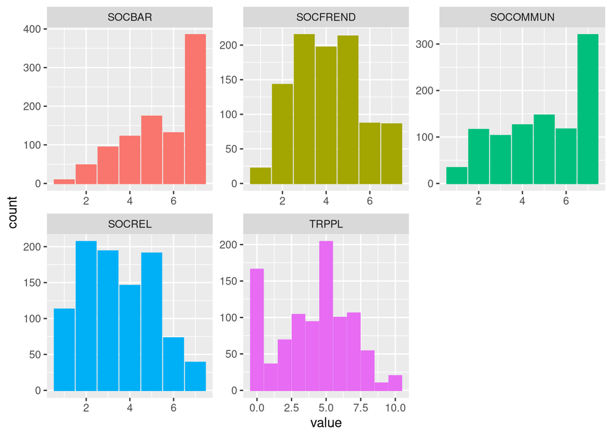

```r
socialVarNames = c("SOCREL", "SOCOMMUN","SOCFREND","SOCBAR","TRPPL")
social.long <- data |> pivot_longer(all_of(socialVarNames),names_to = "variable", values_to = "value")

ggplot(social.long, aes(x=value, color=variable,fill=variable)) +
  facet_wrap(~variable, scales='free', ncol=3) +
  geom_bar() +
  theme(legend.position = "none")
```

### Modeling and Results

#### Preparing data for MCA

When running MCA analysis, an $IxJ$ indicator matrix is created where $I$ is the number of observations and $J = \sum^{P}_{p=1}j_p$ with $P$ being the number of variables in the original dataset and $j_p$ being the number of observation levels of variable $p$. This means that $J$ will be large when there are many observation levels of each variable; also, this causes problems when dealing with ordinal data, as the each ordinal level will essentially have an indicator variable created for it during MCA. This can be corrected by transforming the ordinal variables in the original dataset into boolean categorical variables which equal 1 if the response was higher than the median and 0 if less than or equal to the median.

```r
#data columns to exclude from MCA
MCAexclude = suppVarNames

likert2Boolean <- function(x){
  (x>median(data[[cur_column()]])) |>         #this will be a boolean that will be true if x is greater than the median of the column
    as.integer() |> as.factor()               #then turning boolean into an integer for ease of reading graph and then into a factor
}

#creating dataframe that ONLY has supplementary variables
suppVars = data |> select(all_of(suppVarNames)) |>
  mutate(across(all_of(c("ATTEND", "RELPERSN", "RELACTIV")),likert2Boolean)) |>
  mutate(across(!all_of(c("EDUC","AGE","CHILDS")),factor))  # here I'm making all the columns EXCEPT for EDUC, AGE, and CHILDS into factors because these three are numeric


MCAdata <- data |>
  select(!all_of(MCAexclude)) |>                        # selecting variables not in the excluded set
  mutate(across(everything(),likert2Boolean))      # applying my likert to boolean function

#Create dataframe with both MCA vars and supp vars
MCAdataWithSups <- cbind(MCAdata,suppVars)

#Creare a vector with the indices of all supplementary variables
suppIndices = length(MCAdata)+1:length(MCAdataWithSups)

#Create a vector with the indices of all quantitative variables (which should also be supplementary)
supQuantInd <-  which(sapply(MCAdataWithSups,class) != 'factor')

#create a vector of all qualitative variables
QualInd <-  which(sapply(MCAdataWithSups,class) == 'factor')
#create a vector of all SUPPLEMENTARY qualitative variables
supQualInd <- QualInd[QualInd %in% suppIndices]
```

#### MCA Analysis

An MCA analysis is run on all the varaibles relating to sociability and digital engagement.

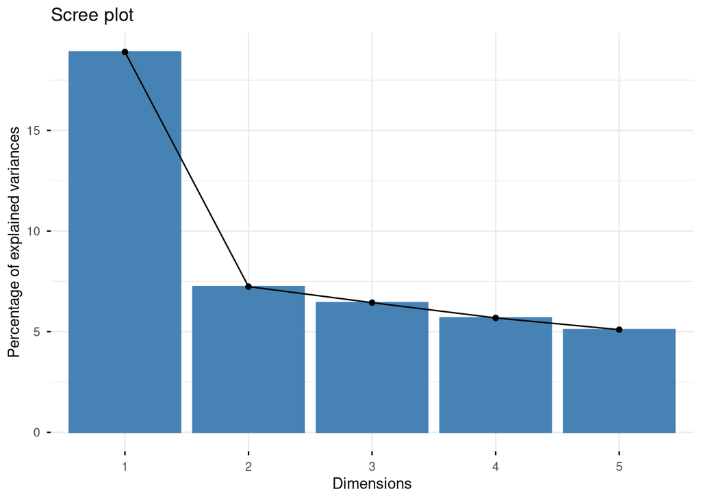

```r
res.mca <- MCA(MCAdata,graph=FALSE)
res.mca.withsupps <- MCA(MCAdataWithSups,graph=FALSE,quanti.sup = supQuantInd,quali.sup = supQualInd)
fviz_eig(res.mca)
```

As can be seen from the above scree plot, there is one dominant component which explains a relatively high percentage of the total variance, with the remaining components explaining a comparatively much lesser amount of variance. The biggest difference between people in this project is related to how they use technology and the internet. The first dimension explains approximately 19% of the total variance, making it the dominant latent dimension, while the second dimension explains about 7.3%. After the first dimension, the percentage of explained variance declines substantially, with subsequent dimensions each accounting for a relatively small proportion of the total variation. This pattern indicates that the primary differences among respondents are captured by the first dimension, which is interpreted as digital capital, reflecting variation in digital technology use and internet engagement. The second dimension captures a smaller but meaningful amount of variation and is interpreted as social capital, representing differences in social interaction and participation. Together, these two dimensions provide the most informative summary of the relationships among the digital engagement and sociability variables used in this study.

```r
get_mca(res.mca)$contrib |> kable(digits=3) |> kable_styling() |>
  column_spec(2,color = ifelse(get_mca(res.mca)$contrib[,1] > 1, "red","black")) |>
  column_spec(3,color = ifelse(get_mca(res.mca)$contrib[,2] > 1, "red","black")) |>
  column_spec(4,color = ifelse(get_mca(res.mca)$contrib[,3] > 1, "red","black")) |>
  column_spec(5,color = ifelse(get_mca(res.mca)$contrib[,4] > 1, "red","black")) |>
  column_spec(6,color = ifelse(get_mca(res.mca)$contrib[,5] > 1, "red","black"))
```

|  | Dim 1 | Dim 2 | Dim 3 | Dim 4 | Dim 5 |
| --- | --- | --- | --- | --- | --- |
| SOCREL_0 | 0.003 | 2.297 | 4.743 | 0.166 | 11.824 |
| SOCREL_1 | 0.003 | 2.630 | 5.430 | 0.190 | 13.535 |
| SOCOMMUN_0 | 0.001 | 2.639 | 7.068 | 0.029 | 0.565 |
| SOCOMMUN_1 | 0.001 | 3.177 | 8.507 | 0.035 | 0.680 |
| SOCFREND_0 | 0.400 | 3.915 | 4.881 | 0.123 | 1.198 |
| SOCFREND_1 | 0.598 | 5.852 | 7.297 | 0.184 | 1.791 |
| SOCBAR_0 | 0.433 | 3.821 | 0.982 | 0.335 | 2.254 |
| SOCBAR_1 | 0.650 | 5.737 | 1.474 | 0.504 | 3.384 |
| INTRNETUSE_0 | 3.022 | 0.335 | 0.029 | 10.917 | 0.244 |
| INTRNETUSE_1 | 3.562 | 0.395 | 0.034 | 12.868 | 0.288 |
| INTPRFSSNL_0 | 2.132 | 0.198 | 0.003 | 2.639 | 0.617 |
| INTPRFSSNL_1 | 3.387 | 0.315 | 0.004 | 4.193 | 0.981 |
| UNPLUG_0 | 0.006 | 1.216 | 0.621 | 4.128 | 1.507 |
| UNPLUG_1 | 0.007 | 1.410 | 0.719 | 4.785 | 1.747 |
| INTHOME_0 | 1.098 | 1.557 | 0.232 | 8.890 | 0.176 |
| INTHOME_1 | 1.783 | 2.529 | 0.377 | 14.437 | 0.285 |
| INTPUB_0 | 1.450 | 2.321 | 0.049 | 1.059 | 0.101 |
| INTPUB_1 | 3.399 | 5.440 | 0.114 | 2.482 | 0.236 |
| INTSKILL_0 | 5.643 | 0.684 | 0.023 | 2.597 | 0.026 |
| INTSKILL_1 | 7.976 | 0.967 | 0.032 | 3.671 | 0.037 |
| INTSURF_0 | 5.442 | 1.150 | 0.133 | 2.910 | 0.087 |
| INTSURF_1 | 8.030 | 1.697 | 0.196 | 4.294 | 0.129 |
| INTLITERACY_0 | 2.849 | 1.775 | 1.214 | 2.764 | 0.094 |
| INTLITERACY_1 | 4.132 | 2.575 | 1.761 | 4.008 | 0.136 |
| INTAPPS_0 | 3.022 | 0.019 | 0.003 | 2.469 | 0.262 |
| INTAPPS_1 | 6.647 | 0.042 | 0.007 | 5.430 | 0.575 |
| INTCOMM_0 | 4.462 | 0.112 | 0.027 | 0.336 | 1.199 |
| INTCOMM_1 | 4.490 | 0.113 | 0.028 | 0.338 | 1.207 |
| INTSHARE_0 | 0.714 | 0.825 | 0.162 | 0.129 | 0.000 |
| INTSHARE_1 | 1.402 | 1.620 | 0.318 | 0.253 | 0.000 |
| INTSEARCH_0 | 4.012 | 1.304 | 0.001 | 0.140 | 0.522 |
| INTSEARCH_1 | 4.730 | 1.538 | 0.001 | 0.164 | 0.615 |
| INTGAME_0 | 0.433 | 3.785 | 0.797 | 0.038 | 2.836 |
| INTGAME_1 | 0.591 | 5.171 | 1.089 | 0.052 | 3.875 |
| INTSTREAM_0 | 2.521 | 0.599 | 0.001 | 0.000 | 1.481 |
| INTSTREAM_1 | 3.358 | 0.798 | 0.001 | 0.000 | 1.972 |
| INTFNCL_0 | 1.710 | 0.031 | 0.020 | 0.054 | 0.313 |
| INTFNCL_1 | 4.257 | 0.077 | 0.049 | 0.135 | 0.780 |
| INTMEET_0 | 0.188 | 2.597 | 5.708 | 0.459 | 0.647 |
| INTMEET_1 | 0.503 | 6.948 | 15.273 | 1.229 | 1.730 |
| INTLNLY_0 | 0.118 | 0.984 | 6.264 | 0.050 | 0.011 |
| INTLNLY_1 | 0.393 | 3.267 | 20.786 | 0.165 | 0.035 |
| INTVIEWS_0 | 0.000 | 0.000 | 0.000 | 0.000 | 0.000 |
| INTRUST_0 | 0.195 | 6.436 | 0.230 | 0.111 | 5.771 |
| INTRUST_1 | 0.208 | 6.864 | 0.245 | 0.118 | 6.155 |
| TRPPL_0 | 0.011 | 0.673 | 0.924 | 0.037 | 8.460 |
| TRPPL_1 | 0.026 | 1.561 | 2.144 | 0.085 | 19.632 |

When the variables are plotted on the axis representing the principle components, we see clear patterns. In this plot, the variables with “_1” in the name represent the cases where respondents responded in a category higher than the median. Axis 1 appears to capture variation due to overall skill or usage of digital technology while dimension 2 captures variation due to sociability. The direction of these effects must be noted - higher values on Dimension 1 indicate a higher response category, which in turn reflects a lower usage of and skill with digital technologies. A higher vale on dimension 2 correlates with a lower frequency of social events and generally more pessimistic views on social interaction.

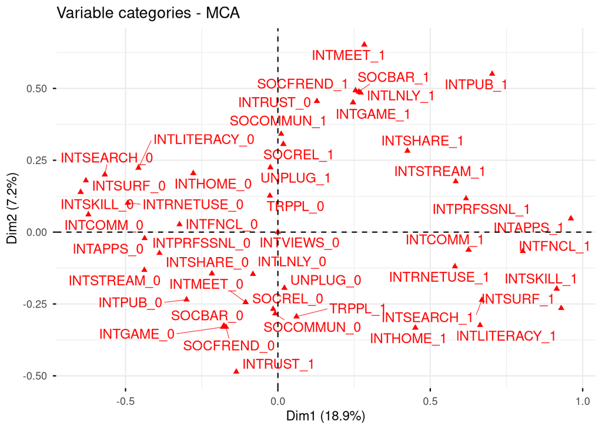

```r
fviz_mca_var(res.mca, repel=T)
```

This graph shows that high digital skills and frequent internet use (INTSKILL_1, INTSURF_1, INTAPPS_1, INTSEARCH_1, INTCOMM_1, INTRNETUSE_1, INTSTREAM_1) are all cluster on the right side of the graph, with high positive coordinates on Dimension 1. This confirms that these variables strongly define Digital Capital. Their opposite categories (INTSKILL_0, INTSURF_0) cluster on the left side, representing low digital skills and infrequent use.

The below graph shows the correlation between each variable and the first two components. The same results are visible as above.

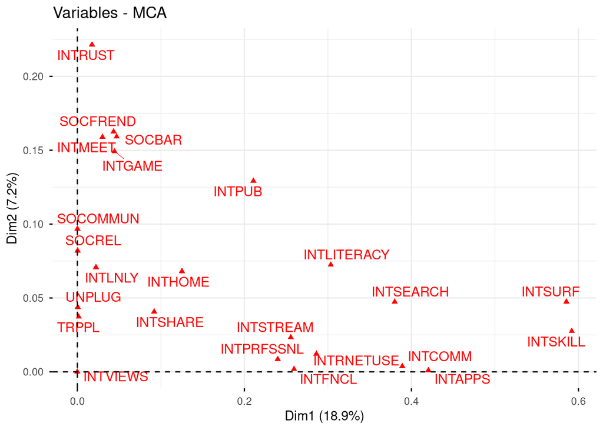

```r
fviz_mca_var(res.mca, repel=T, choice='var')
```

An interesting result of these graphs is the positioning of some digital engagement variables that appear to correlate more closely with dimension 2 compared to dimension 1. These variables include “INTMEET”, “INTGAME”, and ‘INTTRUST’, which are variables which capture some social dimension of digital engagement.

A plot with dimensions 2 and 3 is shown below

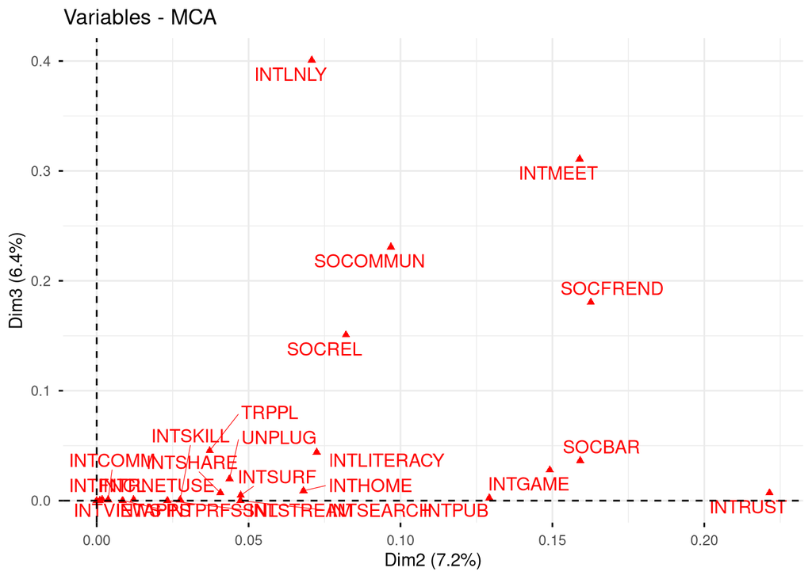

```r
fviz_mca_var(res.mca, axes=c(2,3),repel=T, choice='var')
```

The graph below shows contributions of all active variables to Dimension 1 (explaining 19% of the variance) and Dimension 2 (explaining 7.3% of the variance), with supplementary demographic variables (like age, education, marital status, sex, etc.), and projected onto the same two-dimensional space. So we can see how demographic characteristics relate to Digital Capital (Dimension 1) and Social Capital (Dimension 2). The digital and social categories stay the same positions as in the previous graph: High digital skill variables (INTSKILL_1, INTSURF_1, INTAPPS_1, etc.) cluster on the right side, while social variables such as INTRUST, SOCFREND, and SOCBAR are positioned along Dimension 2. The most of the supplementary variables are close to the origin, meaning that they have a very small correlation with the two dimensions. However, ‘age’ and ‘work status’ both have a slightly higher correlation with both dimensions when compared with other supplementary variables.

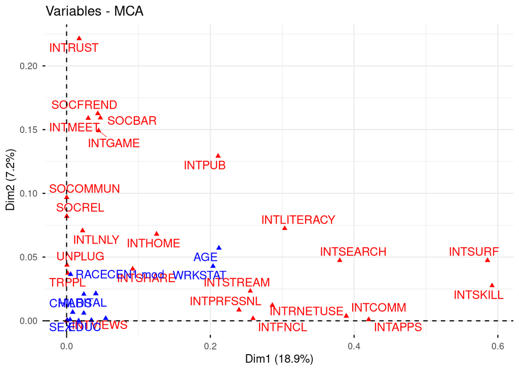

```r
fviz_mca_var(res.mca.withsupps, repel=T, choice='var')
```

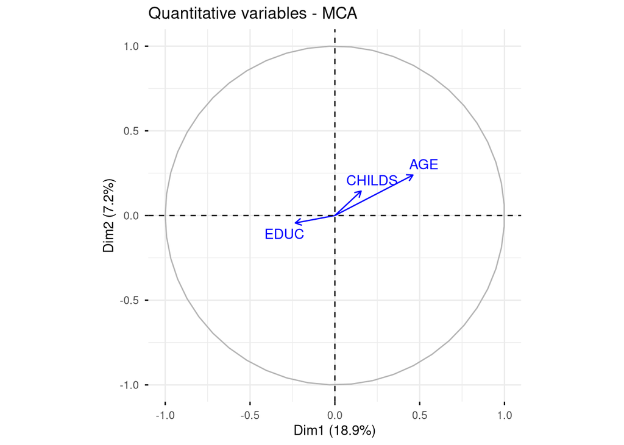

```r
fviz_mca_var(res.mca.withsupps, repel=T, choice='quanti.sup')
```

The correlation plot shows the relationships between demographic variables and the first two MCA dimensions. Dimension 1 (19%) is most strongly associated with Age, while Children (CHILDS) has a weaker positive association with both dimensions. Education (EDUC) points in the opposite direction of Age along Dimension 1, suggesting that higher educational attainment is associated with lower values on this dimension. Overall, the relatively short vectors indicate that demographic variables explain only a small portion of the variation in the MCA dimensions, with Age contributing the most.

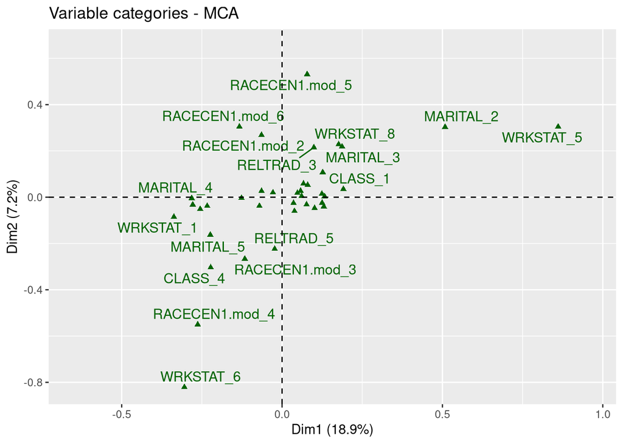

```r
fviz_mca_var(res.mca.withsupps, repel=T, invisible='var')
```

The MCA category plot displays the positions of the categorical variable levels across the first two dimensions. Categories that are located close together represent similar response patterns, while categories farther from the origin contribute more strongly to the underlying dimensions. Employment status (WRKSTAT), particularly WRKSTAT_5, is located furthest along Dimension 1, indicating that it has one of the strongest associations with the latent structure. Categories related to religious participation (ATTEND and RELTRAD), marital status (MARITAL), social relationships (RELPERSN), and social class (CLASS) are more clustered around the center, suggesting more moderate contributions to the two dimensions. Overall, the plot indicates that employment status contributes more strongly to the latent dimensions than most of the other demographic categories.

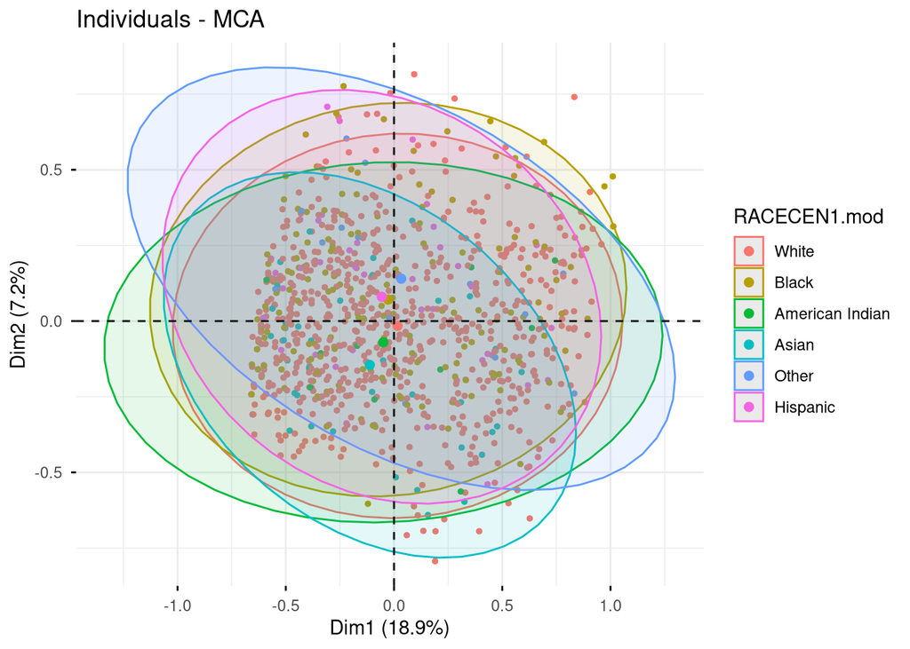

```r
fviz_mca_ind(res.mca.withsupps, repel=T, label="none",addEllipses=T,habillage= 27, pointsize=1)+ guides(fill="none") + scale_color_discrete(labels=(c("White","Black","American Indian","Asian","Other","Hispanic")))
```

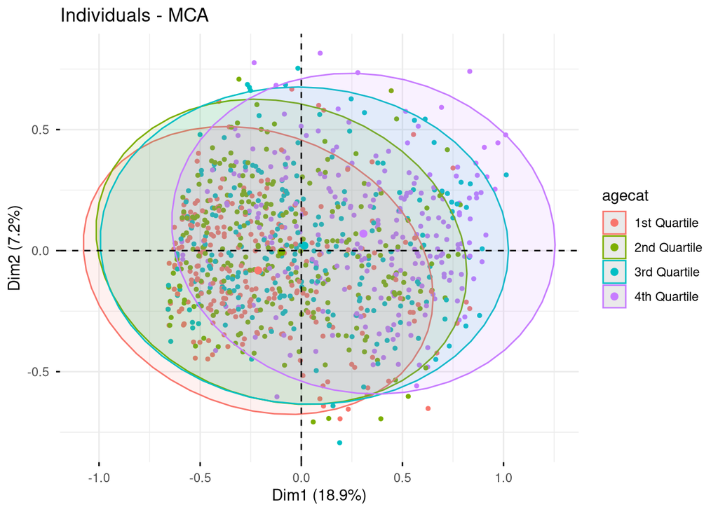

```r
agecats <- data |> mutate(agecat = case_when(
  AGE <= quantile(AGE, 0:4/4)[2] ~ 1,
  AGE <= quantile(AGE, 0:4/4)[3] ~ 2,
  AGE <= quantile(AGE, 0:4/4)[4] ~ 3,
  AGE <= quantile(AGE, 0:4/4)[5] ~ 4
) |> as.factor()
) |> select(agecat)

MCAdata.with.agecats = cbind(MCAdata,agecats)

res.mca.agecats <- MCA(MCAdata.with.agecats,graph=FALSE,quali.sup =25)
fviz_mca_ind(res.mca.agecats, repel=T, label="none",addEllipses=T,habillage= 25, pointsize=1)+ guides(fill="none") + scale_color_discrete(labels=(c("1st Quartile","2nd Quartile", "3rd Quartile", "4th Quartile")))
```

The above two plots show the point cloud of individuals categorized by two of the demographic supplementary variables and with confidence elipses; in the first, they are categorized according to race and in the second by the age quartile. As can be seen, there is poor seperation between the racial groups, with most of the confidence elipses overlapping, though it is clear that there are some differences. As the majority of the survey sample was white, the barycenter of the white demographic group is close to the origin of the plot and so the locations of the other groups can be seen as showing the difference compared to the white group. Overall, Asian-Americans appear to be associated with both moderately higher social and digital capital. The “Other” Category also was notably lower in social capital. When looking at the graph which categorizes individuals by age quartile, a greater degree of separation between categories is apparent, though there is still some overlap. The oldest quartile appears to have the greatsertt difference from the three younger quartiles, though each successive quartile shows a decrease in both social and digital capital.

## Conclusion

The results indicate that two meaningful latent dimensions emerge from the data. The first dimension captures variation in digital technology use and is interpreted as digital capital, reflecting differences in individuals’ engagement with digital technologies. The second dimension represents patterns of social interaction and participation and is interpreted as social capital. Together, these dimensions provide a useful framework for understanding how digital engagement and social connectedness are related.

One of the most notable findings is that several technology-related variables—including online gaming (INTGAME), comfort meeting people online (INTMEET), and trust in online contacts (INTRUST)—are more strongly associated with the social capital dimension than with the digital capital dimension. This suggests that digital technologies are not only tools for accessing information but also important platforms for building and maintaining social relationships. The findings therefore indicate that digital capital and social capital are interconnected rather than independent constructs.

Demographic variables generally showed weaker associations with both latent dimensions than measures of digital behavior and social interaction. However, age and employment status were notable exceptions. Older respondents tended to exhibit lower levels of both digital capital and social capital. Similarly, retired individuals were associated with lower scores on both dimensions, while respondents who were currently in school tended to exhibit higher levels of both digital and social capital. These patterns are likely influenced by age, as retired individuals are generally older and students are typically younger.

Several limitations should be considered when interpreting these findings. First, the analytic sample (n = 975) contains a higher proportion of respondents with higher levels of education than the general U.S. population, which may limit the generalizability of the results, particularly for populations that experience greater digital inequality. Second, twenty-four Likert-scale variables were dichotomized into binary variables using median splits to facilitate MCA. Although this approach simplifies interpretation, it also reduces variation in the data and may obscure meaningful differences in respondents’ attitudes and behaviors.

Future research should build on these findings by examining whether the relationships between digital capital and social capital remain consistent across different demographic groups, such as urban and rural residents, younger and older adults, or individuals with varying educational backgrounds. Because the GSS provides cross-sectional data, future studies could also incorporate multiple survey waves or longitudinal data to examine how digital engagement and social capital evolve over time and to better assess potential causal relationships. Such research would contribute to a more comprehensive understanding of the role of digital engagement in shaping social inequality and community participation.

## References

Abdi, Hervé, and Dominique Valentin. 2007. “Multiple Correspondence Analysis.” *Encyclopedia of Measurement and Statistics*, January.

Card, Kiffer, and Jorge Andrés Delgado-Ron. 2025. “Do Rural–Urban Differences in Social Environments Act as Barriers to Social Wellbeing? A Cross-Sectional Study.” *Urban Science* 9 (7): 248. https://doi.org/10.3390/urbansci9070248.

Davern, Michael, Rene Bautista, Jeremy Freese, Pamela Herd, and Stephen L. Morgan. 2026. *General Social Survey 1972-2024*.

Deursen, A. J. A. M. van, and J. A. G. M. van Dijk. 2019. “The First-Level Digital Divide Shifts from Inequalities in Physical Access to Inequalities in Material Access.” *New Media & Society* 21 (2): 354–75.

Gannon, Brenda, and Jennifer Roberts. 2020. “Social Capital: Exploring the Theory and Empirical Divide.” *Empirical Economics* 58 (3): 899–919. https://doi.org/10.1007/s00181-018-1556-y.

Gewers, Felipe L., Gustavo R. Ferreira, Henrique F. De Arruda, et al. 2022. “Principal Component Analysis: A Natural Approach to Data Exploration.” *ACM Computing Surveys* 54 (4): 1–34. https://doi.org/10.1145/3447755.

Greenacre, Michael, Patrick J. F. Groenen, Trevor Hastie, Alfonso Iodice D’Enza, Angelos Markos, and Elena Tuzhilina. 2022. “Principal Component Analysis.” *Nature Reviews Methods Primers* 2 (1): 100. https://doi.org/10.1038/s43586-022-00184-w.

Hooghe, Marc, and Jennifer Oser. 2015. “Internet, Television and Social Capital: The Effect of ‘Screen Time’ on Social Capital.” *Information, Communication & Society* 18 (10): 1175–99. https://doi.org/10.1080/1369118X.2015.1022568.

Husson, François, Sébastien Lê, and Jérôme Pagès. 2017. *Exploratory Multivariate Analysis by Example Using r*. CRC Press.

Lybeck, Robin, Ilkka Koiranen, and Aki Koivula. 2024. “From Digital Divide to Digital Capital: The Role of Education and Digital Skills in Social Media Participation.” *Universal Access in the Information Society* 23 (4): 1657–69. https://doi.org/10.1007/s10209-022-00961-0.

Lythreatis, S., S. K. Singh, and A.-N. El-Kassar. 2022. “The Digital Divide: A Review and Future Research Agenda.” *Technological Forecasting and Social Change* 175: 121359. https://doi.org/10.1016/j.techfore.2021.121359.

Pierce, G. L., and P. F. Cleary. 2024. “The Persistent Educational Digital Divide and Its Impact on Societal Inequality.” *PLOS ONE* 19 (4).

Reddick, C. G., R. Enriquez, R. J. Harris, and B. Sharma. 2020. “Determinants of Broadband Access and Affordability: An Analysis of a Community Survey on the Digital Divide.” *Cities* 106: 102904.

Reddick, Christopher, Roger Enriquez, Richard Harris, and Judith Flores. 2024. “Understanding the Levels of Digital Inequality Within the City: An Analysis of a Survey.” *Cities* 148 (May): 104844. https://doi.org/10.1016/j.cities.2024.104844.

Ruiu, Maria Laura, and Massimo Ragnedda. 2020. “Digital Capital and Online Activities: An Empirical Analysis of the Second Level of Digital Divide.” *First Monday*, ahead of print, June. https://doi.org/10.5210/fm.v25i7.10855.